# Analyses

Ian Hussey

28 October, 2024

# Dependencies

```r
library(tidyverse)
library(readxl)
library(janitor)
library(irr)
library(afex)
library(emmeans)
library(effectsize)
library(knitr)
library(kableExtra)
```

# Get data

```r
data_study1 <- read_xlsx("Results_sheet_study1_hussey_elson.xlsx") |>
  clean_names() |>
  filter(participant_id < 1000) |>
  select(participant_id,
         # methods variables
         condition, target_word, time_pressure_order,
         # individual raters' scores
         target_low1_coder1, target_low2_coder1, target_high1_coder1, target_high2_coder1,
         nontarget_low1_coder1, nontarget_low2_coder1, nontarget_high1_coder1, nontarget_high2_coder1,
         target_low1_coder2, target_low2_coder2, target_high1_coder2, target_high2_coder2,
         nontarget_low1_coder2, nontarget_low2_coder2, nontarget_high1_coder2, nontarget_high2_coder2,
         # compound variables already scored in the excel sheet
         mean_target_low, mean_target_high, mean_nontarget_low, mean_nontarget_high)

data_study2 <- read_xlsx("Results_sheet_study2_hussey_elson.xlsx") |>
  clean_names() |>
  filter(participant_id < 1000) |>
  select(participant_id,
         # method variables
         condition, targetword,
         # individual raters' scores
         mentions_period2_coder1 = a_period_2_coder1,
         rings_period2_coder1 = b_period_2_coder1,
         both_period2_coder1 = c_period_2_coder1,
         mentions_period2_coder2 = a_period_2_coder2,
         rings_period2_coder2 = b_period_2_coder2,
         both_period2_coder2 = c_period_2_coder2,
         # compound variables already scored in the excel sheet
         sum_score = sum_abc_period2_final) |>
  mutate(all_period2_coder1 = mentions_period2_coder1 + rings_period2_coder1 + both_period2_coder1,
         all_period2_coder2 = mentions_period2_coder2 + rings_period2_coder2 + both_period2_coder2)

data_study2_narrow <- read_xlsx("Results_sheet_study2_hussey_elson_all_narrow_scoring.xlsx") |>
  clean_names() |>
  filter(participant_id < 1000) |>
  select(participant_id,
         # method variables
         condition, targetword,
         # individual raters' scores
         mentions_period2_coder1 = a_period_2_coder1,
         rings_period2_coder1 = b_period_2_coder1,
         both_period2_coder1 = c_period_2_coder1,
         mentions_period2_coder2 = a_period_2_coder2,
         rings_period2_coder2 = b_period_2_coder2,
         both_period2_coder2 = c_period_2_coder2,
         # compound variables already scored in the excel sheet
         sum_score = sum_abc_period2_final) |>
  mutate(all_period2_coder1 = mentions_period2_coder1 + rings_period2_coder1 + both_period2_coder1,
         all_period2_coder2 = mentions_period2_coder2 + rings_period2_coder2 + both_period2_coder2)
```

# IRR

## Study 1

```r
cohens_kappa <- function(.data, var1, var2){

  var1_name <- deparse(substitute(var1))
  var2_name <- deparse(substitute(var2))

  res <- .data |>
    select({{ var1 }}, {{ var2 }}) |>
    kappa2()

  .data |>
    summarize(percent_agreement = mean({{ var1 }} == {{ var2 }})*100) |>
    mutate(var1 = var1_name,
           var2 = var2_name,
           kappa = res$value)
}

reliability_results_study1 <-
  bind_rows(
    cohens_kappa(data_study1, target_low1_coder1, target_low1_coder2),
    cohens_kappa(data_study1, target_low2_coder1, target_low2_coder2),
    cohens_kappa(data_study1, target_high1_coder1, target_high1_coder2),
    cohens_kappa(data_study1, target_high2_coder1, target_high2_coder2),
    cohens_kappa(data_study1, nontarget_low1_coder1, nontarget_low1_coder2),
    cohens_kappa(data_study1, nontarget_low2_coder1, nontarget_low2_coder2),
    cohens_kappa(data_study1, nontarget_high1_coder1, nontarget_high1_coder2),
    cohens_kappa(data_study1, nontarget_high2_coder1, nontarget_high2_coder2)
  ) |>
  separate(var1, into = c("trial_type", "condition", "coder")) |>
  select(trial_type, condition, percent_agreement, kappa)

reliability_results_study1 |>
  mutate_if(is.numeric, round_half_up, digits = 2) |>
  kable(align = "r") |>
  kable_classic(full_width = FALSE)
```

| trial_type | condition | percent_agreement | kappa |
| --- | --- | --- | --- |
| target | low1 | 98.75 | 0.96 |
| target | low2 | 100.00 | 1.00 |
| target | high1 | 98.75 | 0.96 |
| target | high2 | 98.75 | 0.96 |
| nontarget | low1 | 100.00 | NaN |
| nontarget | low2 | 100.00 | NaN |
| nontarget | high1 | 98.75 | 0.00 |
| nontarget | high2 | 100.00 | NaN |

## Study 2

```r
calculate_icc21 <- function(.data, var1, var2) {

  var1_name <- deparse(substitute(var1))
  var2_name <- deparse(substitute(var2))

  .data %>%
    select({{ var1 }}, {{ var2 }}) %>%
    psych::ICC() %>%
    .$results %>%
    as_tibble() %>%
    filter(type == "ICC2") %>%
    mutate(var1 = var1_name,
           var2 = var2_name) %>%
    select(var1, var2, ICC21 = ICC, lower = `lower bound`, upper = `upper bound`)
}

reliability_results_study2 <-
  bind_rows(
    calculate_icc21(data_study2, mentions_period2_coder1, mentions_period2_coder2),
    calculate_icc21(data_study2, rings_period2_coder1, rings_period2_coder2),
    calculate_icc21(data_study2, both_period2_coder1, both_period2_coder2),
    calculate_icc21(data_study2, all_period2_coder1, all_period2_coder2)
  ) |>
  separate(var1, into = c("response_type", "time_point", "coder")) |>
  select(response_type, ICC21, lower, upper)

reliability_results_study2 |>
  mutate_if(is.numeric, round_half_up, digits = 2) |>
  kable(align = "r") |>
  kable_classic(full_width = FALSE)
```

| response_type | ICC21 | lower | upper |
| --- | --- | --- | --- |
| mentions | 0.95 | 0.92 | 0.97 |
| rings | 0.92 | 0.82 | 0.96 |
| both | 0.97 | 0.95 | 0.98 |
| all | 0.98 | 0.96 | 0.99 |

## Study 2 - narrow scoring for all stimului

```r
reliability_results_study2_narrow <-
  bind_rows(
    calculate_icc21(data_study2_narrow, mentions_period2_coder1, mentions_period2_coder2),
    calculate_icc21(data_study2_narrow, rings_period2_coder1, rings_period2_coder2),
    calculate_icc21(data_study2_narrow, both_period2_coder1, both_period2_coder2),
    calculate_icc21(data_study2_narrow, all_period2_coder1, all_period2_coder2)
  ) |>
  separate(var1, into = c("response_type", "time_point", "coder")) |>
  select(response_type, ICC21, lower, upper)

reliability_results_study2_narrow |>
  mutate_if(is.numeric, round_half_up, digits = 2) |>
  kable(align = "r") |>
  kable_classic(full_width = FALSE)
```

| response_type | ICC21 | lower | upper |
| --- | --- | --- | --- |
| mentions | 0.91 | 0.86 | 0.94 |
| rings | 0.99 | 0.97 | 0.99 |
| both | 0.96 | 0.93 | 0.97 |
| all | 0.99 | 0.98 | 0.99 |

# Scoring narrow vs broad

## Sanity check scoring is done correctly using a scatter plot

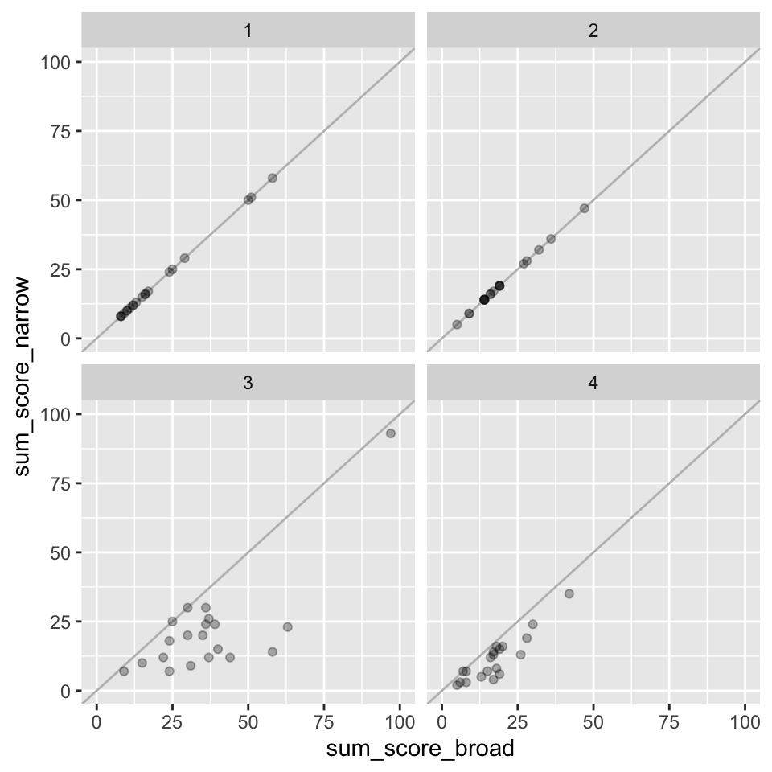

```r
compare_scores <-
  full_join(
    data_study2 |>
      select(participant_id, sum_score_broad = sum_score, targetword),
    data_study2_narrow |>
      select(participant_id, sum_score_narrow = sum_score),
    by = "participant_id"
  ) |>
  mutate(targetword = as.factor(targetword))

ggplot(compare_scores, aes(sum_score_broad, sum_score_narrow)) +
  geom_abline(slope = 1, intercept = 0, color = "grey") +
  geom_point(alpha = 0.3) +
  coord_cartesian(xlim = c(0,100), ylim = c(0,100)) +
  facet_wrap(~ targetword)
```

All looks good - scoring only differed for two target stimuli, and narrow score should always be equal to or lower than broad, and it is.

## Does difference in scoring make a difference?

When the differences in scoring method was raised with the organisers, they suggested that heterogeneity in scoring method between sites was allowable. We think this is a priori undesirable. This analysis checks whether scoring our own data using the broad* method vs narrow method makes a difference to the average of the resulting scores.

*NB technically the broad method is broad-for-two-target-stimuli-and-narrow-for-two, and the narrow method is narrow-for-all-four-target-stimuli.

```r
compare_scores |>
  summarize(mean_score_broad = mean(sum_score_broad),
            sd_score_broad = sd(sum_score_broad),
            mean_score_narrow = mean(sum_score_narrow),
            sd_score_narrow = sd(sum_score_narrow)) |>
  mutate(cohen_d = (mean_score_broad - mean_score_narrow) / sqrt((sd_score_broad^2 + sd_score_narrow^2) / 2)) |>
  mutate_if(is.numeric, round_half_up, digits = 2) |>
  kable(align = "r") |>
  kable_classic(full_width = FALSE)
```

| mean_score_broad | sd_score_broad | mean_score_narrow | sd_score_narrow | cohen_d |
| --- | --- | --- | --- | --- |
| 23.39 | 15.76 | 18.13 | 13.93 | 0.35 |

```r
compare_scores |>
  group_by(targetword) |>
  summarize(mean_score_broad = mean(sum_score_broad),
            sd_score_broad = sd(sum_score_broad),
            mean_score_narrow = mean(sum_score_narrow),
            sd_score_narrow = sd(sum_score_narrow)) |>
  mutate(cohen_d = (mean_score_broad - mean_score_narrow) / sqrt((sd_score_broad^2 + sd_score_narrow^2) / 2)) |>
  mutate_if(is.numeric, round_half_up, digits = 2) |>
  kable(align = "r") |>
  kable_classic(full_width = FALSE)
```

| targetword | mean_score_broad | sd_score_broad | mean_score_narrow | sd_score_narrow | cohen_d |
| --- | --- | --- | --- | --- | --- |
| 1 | 20.10 | 15.40 | 20.10 | 15.40 | 0.0 |
| 2 | 19.40 | 10.07 | 19.40 | 10.07 | 0.0 |
| 3 | 36.60 | 19.04 | 21.55 | 18.35 | 0.8 |
| 4 | 17.45 | 9.06 | 11.45 | 8.16 | 0.7 |

Difference in scoring methods results in a difference in mean scores of Cohen’s d = .35. This may therefore have the potential to introduce heterogeneity between sites.

# Analyses

## Study 1

Using the simpler 2X2 mixed within-between anova from the preregistration.

```r
# Transform data using pivot_longer in tidyverse style
data_study1_long <- data_study1 %>%
  select(participant_id, mean_target_low, mean_target_high, condition_suppression_concentration = condition) |>
  mutate(condition_suppression_concentration = case_when(condition_suppression_concentration == 1 ~ "suppression",
                                                         condition_suppression_concentration == 2 ~ "concentration")) |>
  pivot_longer(cols = c(mean_target_low,
                        mean_target_high),
               names_to = "condition_high_low_pressure",
               values_to = "meancorrectresponse")

# 2 x 2 mixed ANOVA
res_study1 <- aov_ez(id = "participant_id",
                     dv = "meancorrectresponse",
                     between = "condition_suppression_concentration",
                     within = "condition_high_low_pressure",
                     data = data_study1_long)

summary(res_study1)
```

```
##
## Univariate Type III Repeated-Measures ANOVA Assuming Sphericity
##
##                                                                 Sum Sq num Df
## (Intercept)                                                     6.6016      1
## condition_suppression_concentration                             0.8266      1
## condition_high_low_pressure                                     0.1266      1
## condition_suppression_concentration:condition_high_low_pressure 0.0016      1
##                                                                 Error SS den Df
## (Intercept)                                                       5.6969     78
## condition_suppression_concentration                               5.6969     78
## condition_high_low_pressure                                       6.4969     78
## condition_suppression_concentration:condition_high_low_pressure   6.4969     78
##                                                                 F value
## (Intercept)                                                     90.3867
## condition_suppression_concentration                             11.3171
## condition_high_low_pressure                                      1.5195
## condition_suppression_concentration:condition_high_low_pressure  0.0188
##                                                                    Pr(>F)
## (Intercept)                                                     1.124e-14 ***
## condition_suppression_concentration                              0.001193 **
## condition_high_low_pressure                                      0.221401
## condition_suppression_concentration:condition_high_low_pressure  0.891413
## ---
## Signif. codes:  0 '***' 0.001 '**' 0.01 '*' 0.05 '.' 0.1 ' ' 1
```

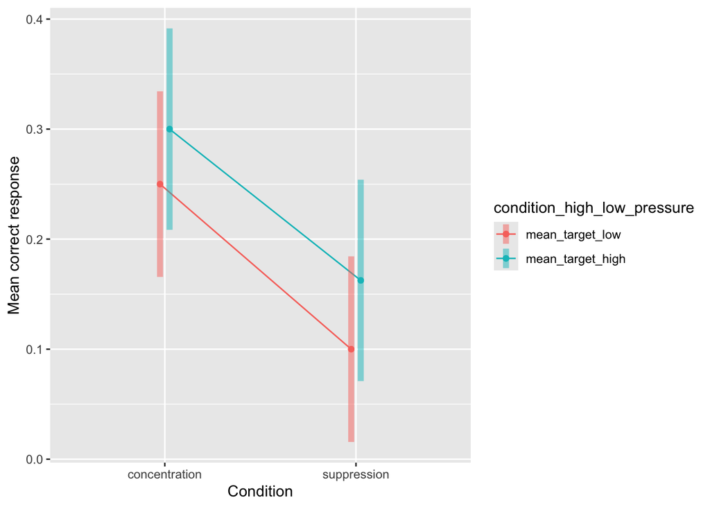

```r
# emmeans(res_study1, pairwise ~ condition_suppression_concentration|condition_high_low_pressure, adjust = "none")
# emmeans(res_study1, pairwise ~ condition_high_low_pressure|condition_suppression_concentration, adjust = "none")

#Plot 2 x 2
# emmip(res_study1, condition_suppression_concentration~condition_high_low_pressure, xlab = "Condition", ylab = "Mean correct response", CIs = T)

emmip(res_study1, condition_high_low_pressure~condition_suppression_concentration, xlab = "Condition", ylab = "Mean correct response", CIs = T)
```

What does `mean correct response` refer to again?? Is the direction of the effect as predicted?

## Study 2

Using a t-test rather than an ANOVA for the pairwise group comparison (ANOVA was used in the prereg), and ignoring the exploratory targetword factor.

```r
data_study2_tidied <- data_study2 |>
  rename(condition_suppression_concentration = condition) |>
  mutate(condition_suppression_concentration =
           case_when(condition_suppression_concentration == 1 ~ "suppression",
                     condition_suppression_concentration == 2 ~ "concentration"))

# 2 x 2 mixed ANOVA
# res_study2 <- aov_ez(id = "participant_id",
#                      dv = "sum_score",
#                      between = c("condition_suppression_concentration", "targetword"),
#                      data = data_study2_tidied)
# summary(res_study2)

t.test(sum_score ~ condition_suppression_concentration,
       data = data_study2_tidied)
```

```
##
##  Welch Two Sample t-test
##
## data:  sum_score by condition_suppression_concentration
## t = -2.1249, df = 68.105, p-value = 0.03723
## alternative hypothesis: true difference in means between group concentration and group suppression is not equal to 0
## 95 percent confidence interval:
##  -14.2036067  -0.4463933
## sample estimates:
## mean in group concentration   mean in group suppression
##                      19.725                      27.050
```

```r
cohens_d(sum_score ~ condition_suppression_concentration,
         data = data_study2_tidied)
```

```
## Cohen's d |         95% CI
## --------------------------
## -0.48     | [-0.92, -0.03]
##
## - Estimated using pooled SD.
```

## Study 2 narrow scored

```r
data_study2_narrow_tidied <- data_study2_narrow |>
  rename(condition_suppression_concentration = condition) |>
  mutate(condition_suppression_concentration =
           case_when(condition_suppression_concentration == 1 ~ "suppression",
                     condition_suppression_concentration == 2 ~ "concentration"))

# 2 x 2 mixed ANOVA
# res_study2_narrow <- aov_ez(id = "participant_id",
#                      dv = "sum_score",
#                      between = c("condition_suppression_concentration", "targetword"),
#                      data = data_study2_narrow_tidied)
# summary(res_study2_narrow)

t.test(sum_score ~ condition_suppression_concentration,
       data = data_study2_narrow_tidied)
```

```
##
##  Welch Two Sample t-test
##
## data:  sum_score by condition_suppression_concentration
## t = -1.672, df = 69.755, p-value = 0.09901
## alternative hypothesis: true difference in means between group concentration and group suppression is not equal to 0
## 95 percent confidence interval:
##  -11.2935609   0.9935609
## sample estimates:
## mean in group concentration   mean in group suppression
##                       15.55                       20.70
```

```r
cohens_d(sum_score ~ condition_suppression_concentration,
         data = data_study2_narrow_tidied)
```

```
## Cohen's d |        95% CI
## -------------------------
## -0.37     | [-0.81, 0.07]
##
## - Estimated using pooled SD.
```